# Ảnh Hưởng Việc Hút Thuốc Của Thai Phụ Đến Cân Nặng Của Trẻ Sơ Sinh

## DỮ LIỆU

- *bwt* (baby weight): cân nặng của em bé sơ sinh, đơn vị ounces (100 ounce=2.83495kg)
- *smoke*: tình trạng hút thuốc của thai phụ (0: không hút, 1: có hút, 9: không xác định)

```python
import numpy as np
import pandas as pd
import matplotlib.pyplot as plt
```

## ĐỌC DỮ LIỆU

Đọc dữ liệu từ file `babies.txt` sử dụng hàm read_csv(). Lưu ý, file `babies.txt` các giá trị dữ liệu cách nhau bằng dấu khoảng trắng, không giống như file csv thông thường cách nhau bằng dấu phẩy ','. Bạn cần truyền thêm một tham số là `sep='\s+'`

```python
df = pd.read_csv('babies.txt', sep='\s+')
df.head()
```

|  | bwt | smoke |
| --- | --- | --- |
| 0 | 120 | 0 |
| 1 | 113 | 0 |
| 2 | 128 | 1 |
| 3 | 123 | 0 |
| 4 | 108 | 1 |

## XEM THÔNG TIN DỮ LIỆU

### Kích Thước

```python
df.shape
```

```
(1236, 2)
```

### Các Trường Dữ Liệu

```python
df.info()
```

```
<class 'pandas.core.frame.DataFrame'>
RangeIndex: 1236 entries, 0 to 1235
Data columns (total 2 columns):
 #   Column  Non-Null Count  Dtype
---  ------  --------------  -----
 0   bwt     1236 non-null   int64
 1   smoke   1236 non-null   int64
dtypes: int64(2)
memory usage: 19.4 KB
```

### Các Đại Lượng Thống Kê

```python
df.describe()
```

|  | bwt | smoke |
| --- | --- | --- |
| count | 1236.000000 | 1236.000000 |
| mean | 119.576861 | 0.464401 |
| std | 18.236452 | 0.912102 |
| min | 55.000000 | 0.000000 |
| 25% | 108.750000 | 0.000000 |
| 50% | 120.000000 | 0.000000 |
| 75% | 131.000000 | 1.000000 |
| max | 176.000000 | 9.000000 |

### Các Giá Trị Dữ Liệu

```python
df.nunique()
```

```
bwt      107
smoke      3
dtype: int64
```

```python
df['smoke'].value_counts()
```

```
0    742
1    484
9     10
Name: smoke, dtype: int64
```

## KHẢO SÁT

### Chia Thành Hai Nhóm

```python
me_hut = df[df['smoke']==1]
me_hut.shape
```

```
(484, 2)
```

```python
me_ko = df[df['smoke']==0]
me_ko.shape
```

```
(742, 2)
```

### So Sánh Các Đại Lượng Thống Kê

```python
me_hut.describe()
```

|  | bwt | smoke |
| --- | --- | --- |
| count | 484.000000 | 484.0 |
| mean | 114.109504 | 1.0 |
| std | 18.098946 | 0.0 |
| min | 58.000000 | 1.0 |
| 25% | 102.000000 | 1.0 |
| 50% | 115.000000 | 1.0 |
| 75% | 126.000000 | 1.0 |
| max | 163.000000 | 1.0 |

```python
me_ko.describe()
```

|  | bwt | smoke |
| --- | --- | --- |
| count | 742.000000 | 742.0 |
| mean | 123.047170 | 0.0 |
| std | 17.398689 | 0.0 |
| min | 55.000000 | 0.0 |
| 25% | 113.000000 | 0.0 |
| 50% | 123.000000 | 0.0 |
| 75% | 134.000000 | 0.0 |
| max | 176.000000 | 0.0 |

### Trực Quan

So sánh bằng boxplot

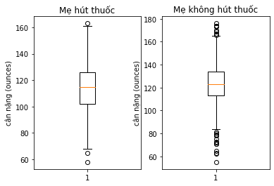

```python
plt.subplot(1, 2, 1)
plt.boxplot(me_hut['bwt'])
plt.title('Mẹ hút thuốc')
plt.ylabel('cân nặng (ounces)')

plt.subplot(1, 2, 2)
plt.boxplot(me_ko['bwt'])
plt.title('Mẹ không hút thuốc')
plt.ylabel('cân nặng (ounces)')

plt.show()
```

So sánh bằng histogram

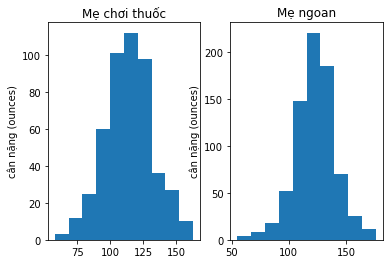

```python
plt.subplot(1, 2, 1)
# plt.hist(me_hut['bwt'], bins=80)
plt.hist(me_hut['bwt'])
plt.title('Mẹ chơi thuốc')
plt.ylabel('cân nặng (ounces)')

plt.subplot(1, 2, 2)
# plt.hist(me_ko['bwt'], bins=80)
plt.hist(me_ko['bwt'])
plt.title('Mẹ ngoan')
plt.ylabel('cân nặng (ounces)')

plt.show()
```